# Reproducible research 2024

mishaal

2024-01-26

## Loading and preprocessing the data

Load the data

```r
if (!file.exists('activity.csv')) {
  unzip('activity.zip',overwrite=TRUE)
}
activity <- read.csv("activity.csv", header = T, sep = ",")
```

There is no need to process/transform the data. It already is in a format suitable for the analysis

## What is mean total number of steps taken per day?

Calculate the total number of steps taken per day

```r
su <- tapply(activity$steps, activity$date, sum, na.rm=T)
```

Histogram of the total number of steps taken each day

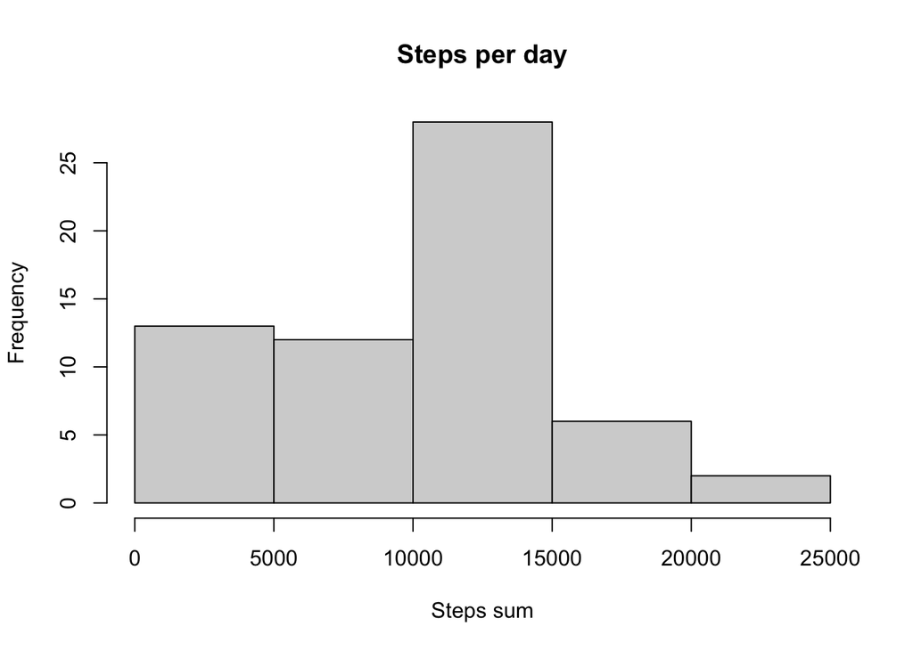

```r
hist(su, xlab = "Steps sum", main = "Steps per day")
```

Calculate and report the mean and median of the total number of steps taken per day

```r
mean_su <- round(mean(su))
median_su <- round(median(su))

print(c("Mean",mean_su))
```

```
## [1] "Mean" "9354"
```

```r
print(c("Median",median_su))
```

```
## [1] "Median" "10395"
```

## What is the average daily activity pattern?

Time series plot (i.e. type = “l”) of the 5-minute interval (x-axis) and the average number of steps taken, averaged across all days (y-axis)

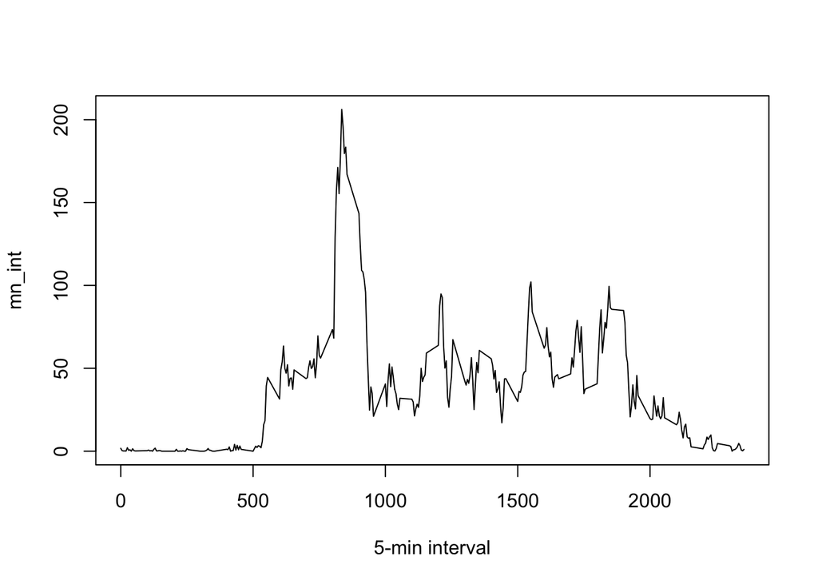

```r
mn_int <- tapply(activity$steps, activity$interval, mean, na.rm=T)
plot(mn_int ~ unique(activity$interval), type="l", xlab = "5-min interval")
```

5-minute interval, on average across all the days in the dataset, which contains the maximum number of steps

```r
mn_int[which.max(mn_int)]
```

```
##      835
## 206.1698
```

## Inputing missing values

Total number of missing values in the dataset

```r
table(is.na(activity) == TRUE)
```

```
##
## FALSE  TRUE
## 50400  2304
```

Strategy for filling in all of the missing values in the dataset: replace any NA with the mean of the corresponding interval

New dataset that is equal to the original dataset but with the missing data filled in

```r
activity2 <- activity
for (i in 1:nrow(activity)){
    if(is.na(activity$steps[i])){
        activity2$steps[i]<- mn_int[[as.character(activity[i, "interval"])]]
    }
}
```

Histogram of the total number of steps taken each day

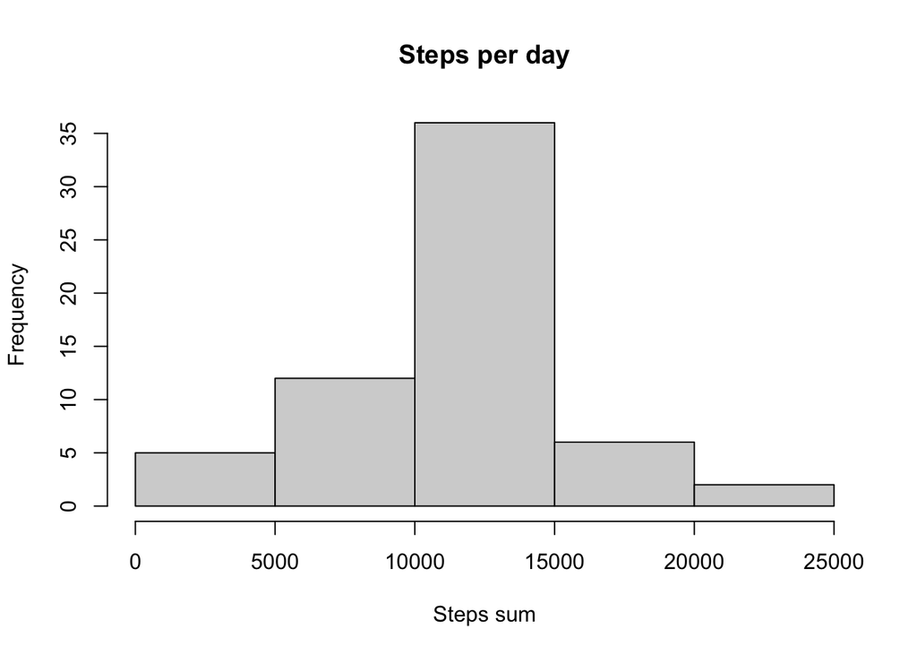

```r
su2 <- tapply(activity2$steps, activity2$date, sum, na.rm=T)
hist(su2, xlab = "Steps sum", main = "Steps per day")
```

New mean and median total number of steps taken per day

```r
mean_su2 <- round(mean(su2))
median_su2 <- round(median(su2))

print(c("New Mean",mean_su2))
```

```
## [1] "New Mean" "10766"
```

```r
print(c("New Median",median_su2))
```

```
## [1] "New Median" "10766"
```

## Are there differences in activity patterns between weekdays and weekends?

Create a new factor variable in the dataset with two levels – “weekday” and “weekend” indicating whether a given date is a weekday or weekend day

```r
Sys.setenv(LANGUAGE = "en")
Sys.setlocale("LC_TIME", "English")
```

```
## [1] ""
```

```r
activity2$weekday <- c("weekday")
activity2[weekdays(as.Date(activity2[, 2])) %in% c("Saturday", "Sunday", "saturday", "sunday"), ][4] <- c("weekend")
activity2$weekday <- factor(activity2$weekday)
```

Make a panel plot containing a time series plot (i.e. type = “l”) of the 5-minute interval (x-axis) and the average number of steps taken, averaged across all weekday days or weekend days (y-axis)

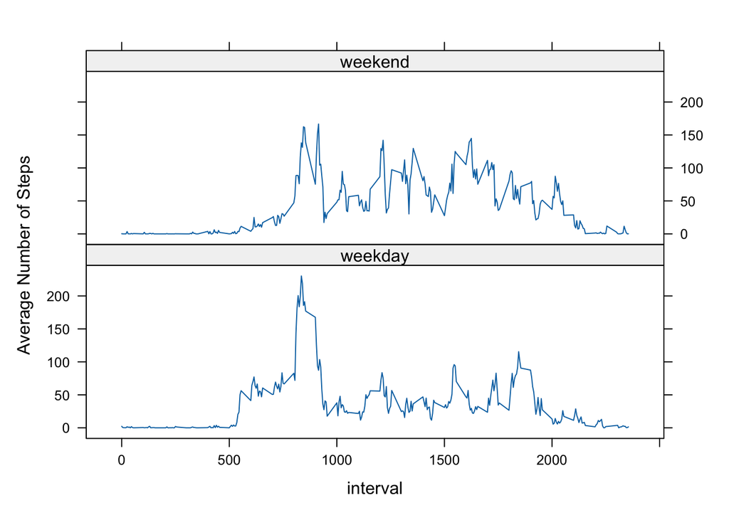

```r
activity2_weekend <- subset(activity2, activity2$weekday == "weekend")
activity2_weekday <- subset(activity2, activity2$weekday == "weekday")
mean_activity2_weekday <- tapply(activity2_weekday$steps, activity2_weekday$interval, mean)
mean_activity2_weekend <- tapply(activity2_weekend$steps, activity2_weekend$interval, mean)

library(lattice)
df_weekday <- data.frame(interval = unique(activity2_weekday$interval), avg = as.numeric(mean_activity2_weekday), day = rep("weekday", length(mean_activity2_weekday)))
df_weekend <- data.frame(interval = unique(activity2_weekend$interval), avg = as.numeric(mean_activity2_weekend), day = rep("weekend", length(mean_activity2_weekend)))
df_final <- rbind(df_weekday, df_weekend)

xyplot(avg ~ interval | day, data = df_final, layout = c(1, 2), type = "l", ylab = "Average Number of Steps")
```